# COVID-19-Spain-Analysis

F.A. Lopez and A. Paez

4/11/2020

This notebook reports our initial analysis of COVID-19 incidence in Spain and the climatic correlates of incidence. The data have been organized in a package for ease of access and distribution. The name of the package is `covid19env` and if necessary can be installed from the GitHub repository.

## Preliminaries

Load packages:

```r
library(covid19env)
library(ggthemes)
library(gridExtra)
library(lubridate)
library(sf)
library(spdep)
library(spsur)
library(tidyverse)
#library(spatialreg)
#library(systemfit)
#library(plm)
#library(splm)
```

Load data from package `covid19env`

```r
data("covid19_spain")
```

Summarize the data:

```r
covid19_spain %>%
  select(-geometry) %>%
  summary()
```

```
##              province                     CCAA         ID_INE
##  Albacete        : 22   Castilla y Leon     :198   Min.   : 1.0
##  Alicante/Alacant: 22   Andalucia           :176   1st Qu.:13.0
##  Almeria         : 22   Castilla - La Mancha:110   Median :25.5
##  Araba/alava     : 22   CataluÃ±a           : 88   Mean   :25.5
##  Asturias        : 22   Galicia             : 88   3rd Qu.:38.0
##  Avila           : 22   Aragon              : 66   Max.   :50.0
##  (Other)         :968   (Other)             :374
##       Date                Cases           Incidence          Population
##  Min.   :2020-03-14   Min.   :    1.0   Min.   :  0.4536   Min.   :  88636
##  1st Qu.:2020-03-19   1st Qu.:  126.0   1st Qu.: 20.0996   1st Qu.: 331549
##  Median :2020-03-24   Median :  378.5   Median : 62.1017   Median : 684202
##  Mean   :2020-03-24   Mean   : 1073.2   Mean   :109.3028   Mean   : 974257
##  3rd Qu.:2020-03-30   3rd Qu.:  957.2   3rd Qu.:148.8700   3rd Qu.:1149460
##  Max.   :2020-04-04   Max.   :36249.0   Max.   :867.5933   Max.   :6663394
##
##      Older         Median_Age     Male2Female          Area
##  Min.   :15.16   Min.   :40.19   Min.   : 91.59   Min.   :1.979e+09
##  1st Qu.:18.02   1st Qu.:42.35   1st Qu.: 95.43   1st Qu.:6.637e+09
##  Median :19.93   Median :43.70   Median : 98.06   Median :1.001e+10
##  Mean   :21.03   Mean   :44.55   Mean   : 97.83   Mean   :1.012e+10
##  3rd Qu.:23.07   3rd Qu.:46.01   3rd Qu.:100.08   3rd Qu.:1.377e+10
##  Max.   :31.36   Max.   :50.68   Max.   :103.01   Max.   :2.179e+10
##
##     Altitude          Coast      Meteo_Station    Max_Temp        Min_Temp
##  Min.   :   5.0   Min.   :0.00   0016A  : 22   Min.   : 3.10   Min.   :-4.700
##  1st Qu.:  24.0   1st Qu.:0.00   0076   : 22   1st Qu.:13.80   1st Qu.: 3.300
##  Median : 215.5   Median :0.00   0367   : 22   Median :16.60   Median : 6.400
##  Mean   : 369.0   Mean   :0.42   1024E  : 22   Mean   :16.25   Mean   : 6.293
##  3rd Qu.: 685.0   3rd Qu.:1.00   1082   : 22   3rd Qu.:19.00   3rd Qu.: 9.100
##  Max.   :1131.0   Max.   :1.00   1111X  : 22   Max.   :25.50   Max.   :18.100
##                                  (Other):968
##    Mean_Temp     Mean_Temp_lag8   Mean_Temp_lag11  Sunshine_Hours
##  Min.   : 1.00   Min.   : 5.763   Min.   : 5.364   Min.   : 0.000
##  1st Qu.: 8.90   1st Qu.:10.162   1st Qu.:10.007   1st Qu.: 2.275
##  Median :11.40   Median :11.994   Median :12.000   Median : 6.350
##  Mean   :11.27   Mean   :12.207   Mean   :12.062   Mean   : 5.972
##  3rd Qu.:13.60   3rd Qu.:13.981   3rd Qu.:13.718   3rd Qu.: 9.500
##  Max.   :21.00   Max.   :19.887   Max.   :19.636   Max.   :12.400
##
```

[output cut: 9 more lines]

```
##  Min.   :0.0000      Min.   :20.96   Min.   :25.55   Min.   :29.44
##  1st Qu.:0.2727      1st Qu.:43.00   1st Qu.:44.94   1st Qu.:45.78
##  Median :0.3636      Median :53.57   Median :51.14   Median :50.85
##  Mean   :0.3682      Mean   :53.79   Mean   :52.03   Mean   :52.39
##  3rd Qu.:0.5455      3rd Qu.:64.49   3rd Qu.:57.74   3rd Qu.:58.18
##  Max.   :1.0000      Max.   :89.51   Max.   :76.51   Max.   :75.85
##
##           geometry
##  MULTIPOLYGON :1100
##  epsg:4326    :   0
##  +proj=long...:   0
##
##
##
##
```

The dataframe is a simple features object with information at the level of the province. The dataframe includes information about the province, including its Autonomous Community (a superior jurisdiction), an identifier, dates, COVID-19 cases and incidence. The period covered is from March 14, 2020 to April 4, 2020. In addition there are some demographic controls, and various climatic variables. Of interest are the lagged variables. The lagged variables are 8-day moving averages calculated using date-minus-12-days to date-minus-5-days, to account for the latency of the infection. More information about the dataset can be obtained by typing `?covid18_spain`.

There are 50 provinces in Spain:

```r
nlevels(covid19_spain$province)
```

```
## [1] 50
```

Shelter in place order in Spain went into effect on March 16, 2020. March 14 is the first day that every province had at least one reported case of COVID-19.

## Data visualization

There are 22 days in the dataset. We can summarize the incidence by week (excluding Canarias):

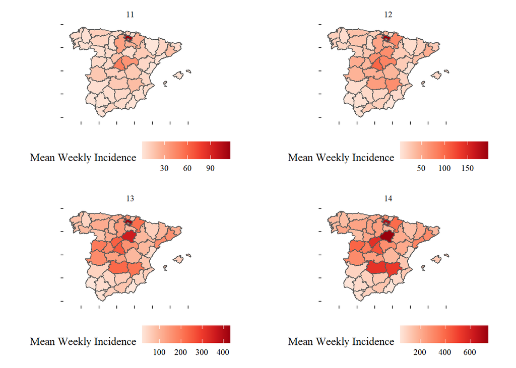

```r
week11.plot <- covid19_spain %>%
  filter(CCAA != "Canarias") %>%
  group_by(province, week = isoweek(Date)) %>%
  summarise(mean_weekly_incidence = mean(Incidence)) %>%
  filter(week == 11) %>%
  ggplot() +
  geom_sf(aes(fill = mean_weekly_incidence)) +
  scale_fill_distiller(name = "Mean Weekly Incidence",
                       palette = "Reds",
                       direction = 1) +
  theme_tufte() +
  theme(axis.text = element_blank(),
        legend.position = "bottom") +
  facet_wrap(~week)

week12.plot <- covid19_spain %>%
  filter(CCAA != "Canarias") %>%
  group_by(province, week = isoweek(Date)) %>%
  summarise(mean_weekly_incidence = mean(Incidence)) %>%
  filter(week == 12) %>%
  ggplot() +
  geom_sf(aes(fill = mean_weekly_incidence)) +
  scale_fill_distiller(name = "Mean Weekly Incidence",
                       palette = "Reds",
                       direction = 1) +
  theme_tufte() +
  theme(axis.text = element_blank(),
        legend.position = "bottom") +
  facet_wrap(~week)

week13.plot <- covid19_spain %>%
  filter(CCAA != "Canarias") %>%
  group_by(province, week = isoweek(Date)) %>%
  summarise(mean_weekly_incidence = mean(Incidence)) %>%
  filter(week == 13) %>%
  ggplot() +
  geom_sf(aes(fill = mean_weekly_incidence)) +
  scale_fill_distiller(name = "Mean Weekly Incidence",
                       palette = "Reds",
                       direction = 1) +
  theme_tufte() +
  theme(axis.text = element_blank(),
        legend.position = "bottom") +
  facet_wrap(~week)

week14.plot <- covid19_spain %>%
  filter(CCAA != "Canarias") %>%
  group_by(province, week = isoweek(Date)) %>%
  summarise(mean_weekly_incidence = mean(Incidence)) %>%
  filter(week == 14) %>%
  ggplot() +
  geom_sf(aes(fill = mean_weekly_incidence)) +
  scale_fill_distiller(name = "Mean Weekly Incidence",
                       palette = "Reds",
                       direction = 1) +
  theme_tufte() +
  theme(axis.text = element_blank(),
        legend.position = "bottom") +
  facet_wrap(~week)

grid.arrange(week11.plot, week12.plot, week13.plot, week14.plot, nrow = 2)
```

We consider two control variables: ratio of male to female in the province, and median age of the population:

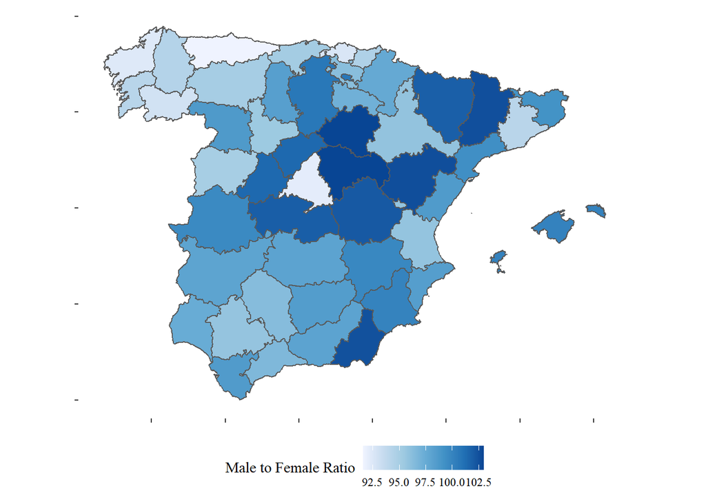

```r
covid19_spain %>%
  filter(CCAA != "Canarias") %>%
  ggplot() +
  geom_sf(aes(fill = Male2Female)) +
  scale_fill_distiller(name = "Male to Female Ratio",
                       palette = "Blues",
                       direction = 1) +
  theme_tufte() +
  theme(axis.text = element_blank(),
        legend.position = "bottom")
```

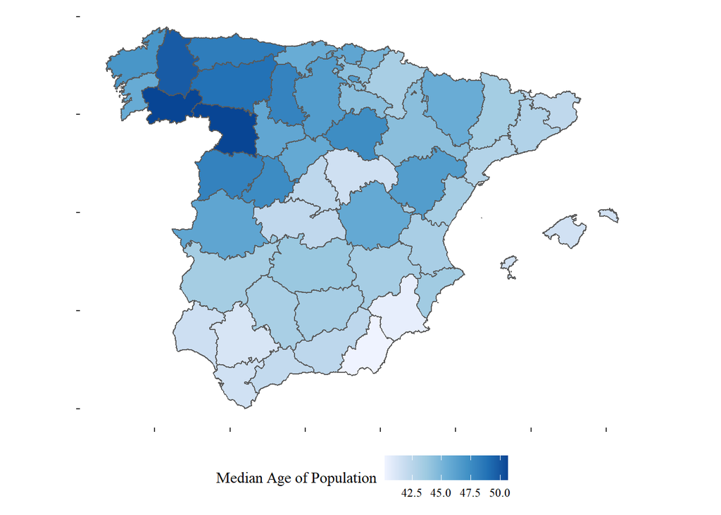

```r
covid19_spain %>%
  filter(CCAA != "Canarias") %>%
  ggplot() +
  geom_sf(aes(fill = Median_Age)) +
  scale_fill_distiller(name = "Median Age of Population",
                       palette = "Blues",
                       direction = 1) +
  theme_tufte() +
  theme(axis.text = element_blank(),
        legend.position = "bottom")
```

We are also interested in the climatic variables. The following plot is the distribution of temperature by CCAA:

```r
# Autonomous communities
ccaa.sf <- covid19_spain %>%
  filter(Date == "2020-03-14") %>%
  group_by(CCAA) %>%
  summarize(provinces = n())

# Extract coordinates of autonomous communities
ccaa.coords <- ccaa.sf %>%
  st_centroid() %>%
  st_coordinates() %>%
  as.data.frame()
```

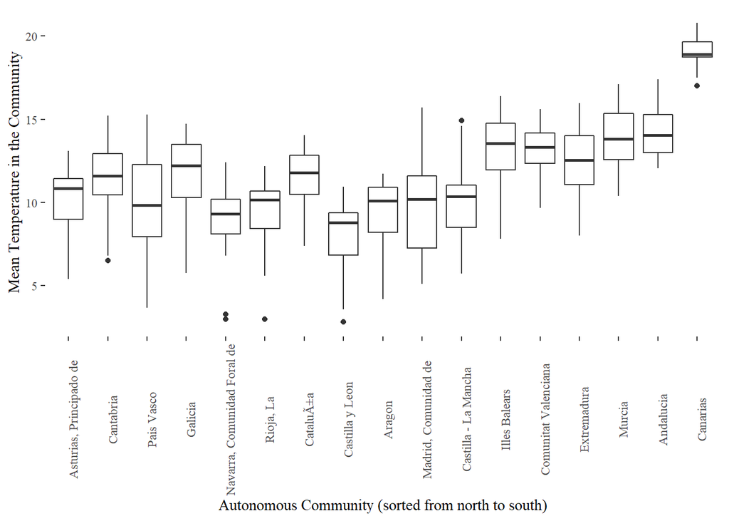

```r
# Join Y coordinate to ccaa.sf
ccaa.sf <- ccaa.sf %>%
  mutate(long = ccaa.coords$Y)

# Sort autonomous communities from north to south
ccaa.levels <- ccaa.sf %>%
  arrange(desc(long)) %>% select(CCAA)

ccaa.levels <- as.character(ccaa.levels$CCAA)

# Relevel autonomous communities
covid19_spain <- covid19_spain %>%
  mutate(CCAA = factor(CCAA, levels = ccaa.levels, ordered = TRUE))

# Boxplots of temperatures
covid19_spain %>%
  st_drop_geometry() %>%
  group_by(CCAA, Date) %>%
  summarize(Mean_Temp = mean(Mean_Temp)) %>%
  ggplot(aes(x = CCAA, y = Mean_Temp)) +
  geom_boxplot() +
  theme_tufte() +
  theme(axis.text.x = element_text(angle = 90)) +
  xlab("Autonomous Community (sorted from north to south)") +
  ylab("Mean Temperature in the Community")
```

## Multivariate analysis: comparison of approaches

### Panel

1. Panel clásico
2. Panel Clásico o Dinámico
- Debe ser un modelo de efectos fijos para recoger la hetereogeneidad entre las distintas provincias (efectos)
- Debería incluir estructura dinámica ya que la serie tiene una fuerte estrutura temporal
- INCONVENIENTE: considera que la incluencia del dato del día anterior es constante (se estima un coeficiente constante)
- INCONVENIENTE: No se pueden incluir varaibles constantes en T. La hetereogeneidad entre provincias queda en el efecto fijo. No podemos por tanto incluir datos sobre estructura de la poblacion.
- INCONVENIENTE: No podemos incorporar efectos espaciales. El paquete **splm** no incluye estimación de paneles dinámicos con efectos espaciales. Tendriamos que hacerlo en matlab con los códigos de P.Elhorst.

### Spatial SUR

2. SUR espacial
- Hay un coeficente para cada variable y cada instante de tiempo. Aunque es posible considerar coeficientes constantes para los periodos temporales que consideremos.
- La hetereoeneidad espacial debemos incorporarla mediante variables explicativas. –> Estructura de la población relacionada con COVID-19.
- Permite incluir varaibles constantes en T.
- la dinámica temporar quedará recogida mediante el término independiente y la estructura de correlaciones en los residuos. EN TODO CASO, ENTIENDO QUE NUESTRO OBJETIVO NO ES EXPLICAR ESA TENEDENCIA TEMPORAL (solo modelizarla para no incurrir en errores)

## Prepare data for SUR analysis

*El modelo debe considerar efectos del ‘individuo’ y del ‘tiempo’ (para incorporar tendencia temporal)**

```r
# Definicion del panel para plm
GPanel <- plm::pdata.frame(covid19_spain %>%
                              st_drop_geometry() %>%
                              select(province,
                                     Date,
                                     Incidence,
                                     Median_Age,
                                     Male2Female,
                                     Mean_Temp_lag8,
                                     Humidity_lag8,
                                     Sunshine_Hours_lag8,
                                     Mean_Temp_lag11,
                                     Humidity_lag11,
                                     Sunshine_Hours_lag11),
                            c("province","Date"))
```

# Modelo SUR espacial

Construcción de W

```r
# Definición matrix de contactos
Wmat <- covid19_spain %>%
  filter(Date == "2020-03-14") %>%
  as("Spatial") %>%
  poly2nb(queen = FALSE) %>%
  nb2mat(zero.policy = T)

Wmat <- (Wmat > 0) * 1

#W <- poly2nb(as(provincias.sf, "Spatial"), queen = FALSE)
#Wmat <- nb2mat(W,zero.policy = T)
#Wmat <- (Wmat>0)*1
# Conexión de las dos provincias que forman Canarias
Wmat[37, 44] <- 1
Wmat[44, 37] <- 1
# 'Paises Catalans'
n = 8
Wmat[9,n] <- 1
Wmat[n,9] <- 1
Wmat[n,47] <- 1
Wmat[47,n] <- 1
Wmat[n,43] <- 1
Wmat[43,n] <- 1
miW <- Wmat/rowSums(Wmat)
listw <- mat2listw(Wmat,style = "W")
```

Se incluyen dos variables de control para recoger la herogeneidad espacial * HM: ratio Hombres/Mujeres (signo esperado +) * EM: Edad media (signo esperado +)

Define formulas with two different lagged variables:

```r
formula_lag8 <- log(Incidence) ~ log(Male2Female) +
  log(Median_Age) +
  log(Mean_Temp_lag8) +
  log(Sunshine_Hours_lag8 + 0.1) +
  log(Humidity_lag8)

formula_lag11 <- log(Incidence) ~ log(Male2Female) +
  log(Median_Age) +
  log(Mean_Temp_lag11) +
  log(Sunshine_Hours_lag11 + 0.1) +
  log(Humidity_lag11)
```

Model with 8-day moving average of climatic variables:

```r
sur.slm_lag8 <- spsur::spsurtime(formula = formula_lag8,
                                  data=GPanel,
                                  time = GPanel$Date,
                                  type = "slm",
                                  fit_method = "3sls",
                                  listw=  listw)
```

```
## Time to fit the model:  0.5  seconds
```

```r
summary(sur.slm_lag8)
```

```
## Call:
## spsur::spsurtime(formula = formula_lag8, data = GPanel, time = GPanel$Date,
##     listw = listw, type = "slm", fit_method = "3sls")
##
##
## Spatial SUR model type:  slm
##
## Equation  1
##                                   Estimate Std. Error t value  Pr(>|t|)
## (Intercept)_1                    56.590345  25.274531  2.2390 0.0254707 *
## log(Male2Female)_1               -7.257491   4.224569 -1.7179 0.0862570 .
## log(Median_Age)_1                -5.919011   2.603779 -2.2732 0.0233170 *
## log(Mean_Temp_lag8)_1            -1.471130   0.421094 -3.4936 0.0005069 ***
## log(Sunshine_Hours_lag8 + 0.1)_1  0.084006   0.155765  0.5393 0.5898443
## log(Humidity_lag8)_1              0.944923   0.483890  1.9528 0.0512497 .
## rho_1                             0.291876   0.139949  2.0856 0.0373813 *
## ---
## Signif. codes:  0 '***' 0.001 '**' 0.01 '*' 0.05 '.' 0.1 ' ' 1
## R-squared: 0.3178
##   Equation  2
##                                  Estimate Std. Error t value  Pr(>|t|)
## (Intercept)_2                    47.94777   22.73704  2.1088   0.03532 *
## log(Male2Female)_2               -7.06368    3.88523 -1.8181   0.06948 .
## log(Median_Age)_2                -3.56330    2.28827 -1.5572   0.11988
## log(Mean_Temp_lag8)_2            -1.54689    0.38837 -3.9831 7.522e-05 ***
## log(Sunshine_Hours_lag8 + 0.1)_2  0.16203    0.16072  1.0081   0.31374
## log(Humidity_lag8)_2              0.83170    0.39156  2.1241   0.03402 *
## rho_2                             0.13439    0.13355  1.0062   0.31466
## ---
## Signif. codes:  0 '***' 0.001 '**' 0.01 '*' 0.05 '.' 0.1 ' ' 1
## R-squared: 0.2951
##   Equation  3
##                                  Estimate Std. Error t value  Pr(>|t|)
## (Intercept)_3                    34.21939   20.09783  1.7026   0.08908 .
## log(Male2Female)_3               -4.42740    3.45589 -1.2811   0.20058
## log(Median_Age)_3                -2.89065    2.03158 -1.4229   0.15523
## log(Mean_Temp_lag8)_3            -1.42479    0.34690 -4.1072 4.482e-05 ***
## log(Sunshine_Hours_lag8 + 0.1)_3  0.16152    0.17799  0.9075   0.36445
## log(Humidity_lag8)_3              0.53806    0.30203  1.7815   0.07527 .
## rho_3                             0.24524    0.11390  2.1530   0.03166 *
```

[output cut: 404 more lines]

```
##  0.9144090
##  0.9254097
##  0.9276195
##  0.9150496
##  0.9312500
##  0.9429089
##  0.9523723
##  0.9736483
##  0.9324938
##  0.9890101
##  0.9964102
##  1.0000000
##
##  R-sq. pooled: 0.7738
##  Breusch-Pagan:  6954  p-value: (   0)
```

Model with 11-day moving average of climatic variables:

```r
sur.slm_lag11 <- spsur::spsurtime(formula = formula_lag11,
                                  data=GPanel,
                                  time = GPanel$Date,
                                  type = "slm",
                                  fit_method = "3sls",
                                  listw=  listw)
```

```
## Time to fit the model:  0.41  seconds
```

```r
summary(sur.slm_lag11)
```

```
## Call:
## spsur::spsurtime(formula = formula_lag11, data = GPanel, time = GPanel$Date,
##     listw = listw, type = "slm", fit_method = "3sls")
##
##
## Spatial SUR model type:  slm
##
## Equation  1
##                                    Estimate Std. Error t value Pr(>|t|)
## (Intercept)_1                     48.413622  26.379511  1.8353 0.066894 .
## log(Male2Female)_1                -5.544849   4.443317 -1.2479 0.212486
## log(Median_Age)_1                 -5.107345   2.746269 -1.8597 0.063346 .
## log(Mean_Temp_lag11)_1            -1.639449   0.582809 -2.8130 0.005047 **
## log(Sunshine_Hours_lag11 + 0.1)_1  0.042746   0.273852  0.1561 0.876006
## log(Humidity_lag11)_1              0.407414   0.550804  0.7397 0.459750
## rho_1                              0.294248   0.134863  2.1818 0.029457 *
## ---
## Signif. codes:  0 '***' 0.001 '**' 0.01 '*' 0.05 '.' 0.1 ' ' 1
## R-squared: 0.2647
##   Equation  2
##                                   Estimate Std. Error t value Pr(>|t|)
## (Intercept)_2                     38.36960   23.45387  1.6360 0.102302
## log(Male2Female)_2                -5.10121    4.02552 -1.2672 0.205503
## log(Median_Age)_2                 -2.81390    2.42078 -1.1624 0.245476
## log(Mean_Temp_lag11)_2            -1.46000    0.50986 -2.8635 0.004316 **
## log(Sunshine_Hours_lag11 + 0.1)_2  0.04241    0.24973  0.1698 0.865196
## log(Humidity_lag11)_2              0.29722    0.45469  0.6537 0.513537
## rho_2                              0.10572    0.11578  0.9131 0.361518
## ---
## Signif. codes:  0 '***' 0.001 '**' 0.01 '*' 0.05 '.' 0.1 ' ' 1
## R-squared: 0.2288
##   Equation  3
##                                   Estimate Std. Error t value  Pr(>|t|)
## (Intercept)_3                     30.18608   20.82864  1.4493 0.1477178
## log(Male2Female)_3                -3.55522    3.59894 -0.9879 0.3235708
## log(Median_Age)_3                 -2.56329    2.14679 -1.1940 0.2328829
## log(Mean_Temp_lag11)_3            -1.41480    0.41213 -3.4329 0.0006327 ***
## log(Sunshine_Hours_lag11 + 0.1)_3  0.16021    0.24604  0.6512 0.5151574
## log(Humidity_lag11)_3              0.20479    0.36642  0.5589 0.5764135
## rho_3                              0.28634    0.10043  2.8511 0.0044862 **
```

[output cut: 412 more lines]

```
##  0.9123114
##  0.9286538
##  0.9270146
##  0.9246910
##  0.9486809
##  0.9571571
##  0.9644521
##  0.9800781
##  0.9371319
##  0.9927857
##  0.9974767
##  1.0000000
##
##  R-sq. pooled: 0.7835
##  Breusch-Pagan:  7461  p-value: (   0)
```

Compare goodness of fit:

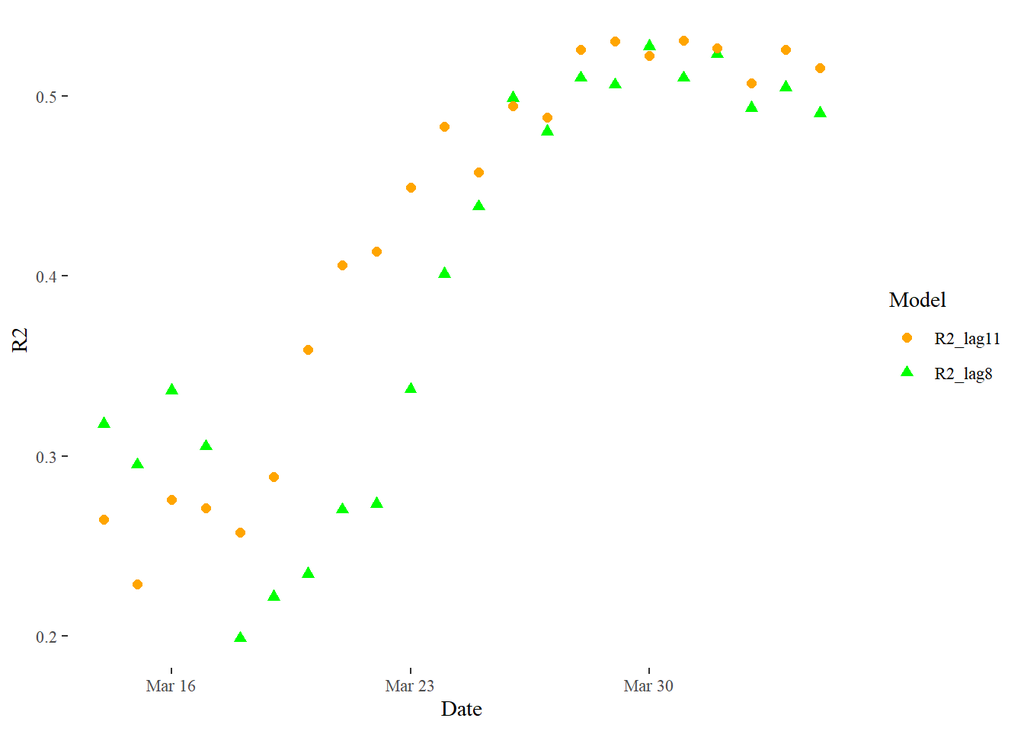

```r
data.frame(R2_lag8 = sur.slm_lag8$R2,
           R2_lag11 = sur.slm_lag11$R2) %>%
  slice(2:n()) %>%
  rownames_to_column(var = "Equation") %>%
  mutate(Date = seq(ymd("2020-03-14"),
                        ymd("2020-04-04"),
                            by = "days")) %>%
  pivot_longer(cols = starts_with("R"), names_to = "Model", values_to = "R2") %>%
  ggplot(aes(x = Date, y = R2, color = Model, shape = Model)) +
  geom_point(size = 2) +
  scale_color_manual(values = c("R2_lag11" = "orange", "R2_lag8" = "green") ) +
  theme_tufte()
```

## Dinámica temporal de la dependencia espacial (Coef lambda estimado en las T=22 ecuaciones)

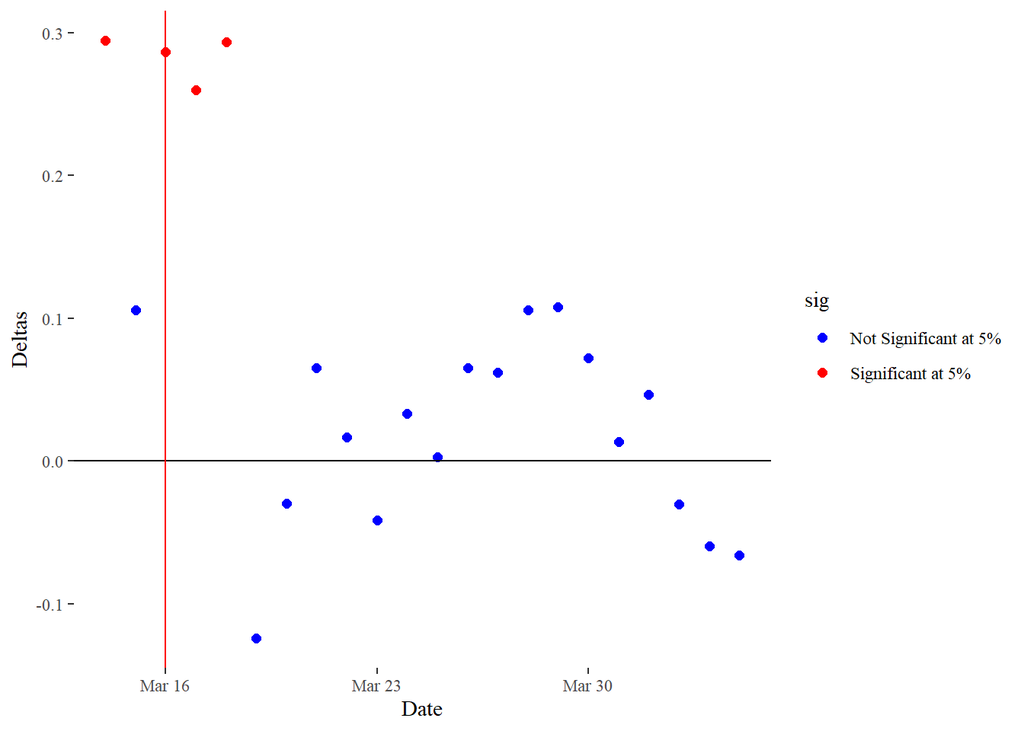

```r
data.frame(Date = seq(ymd("2020-03-14"),
                        ymd("2020-04-04"),
                            by = "days"),
           Deltas = sur.slm_lag11$deltas,
           tvalue = sur.slm_lag11$deltas/sur.slm_lag11$deltas.se) %>%
  mutate(sig = ifelse(abs(tvalue) > 1.64, "Significant at 5%", "Not Significant at 5%")) %>%
  ggplot(aes(x = Date, y = Deltas, color = sig)) +
  geom_point(size = 2) +
  scale_color_manual(values = c("Significant at 5%" = "red", "Not Significant at 5%" = "blue")) +
  geom_hline(yintercept = 0) +
  geom_vline(xintercept = as_date("2020-03-16"), color = "red") +
  theme_tufte()
```

# Analisis of autocorrelated residuals

Extract residuals for March 14 and April 2, and compute autocorrelated residuals on March 14:

```r
residuals_Mar14 <- as.matrix(residuals(sur.slm_lag11))[[1]]
residuals_Mar14 <- lag.listw(listw, residuals_Mar14)

residuals_Apr02 <- as.matrix(residuals(sur.slm_lag11))[[20]]
```

Plot residuals on March 14 (positive autocorrelation):

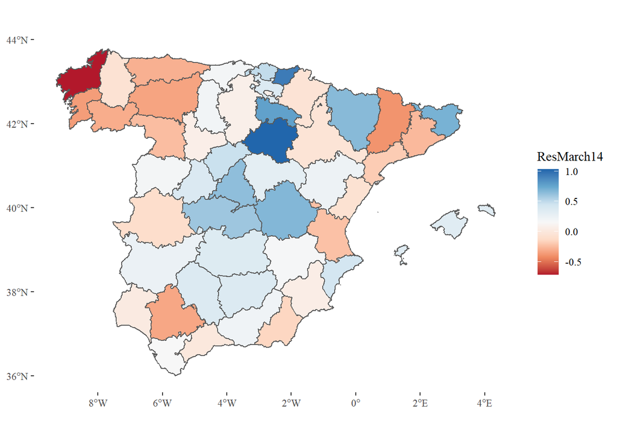

```r
covid19_spain %>% filter(Date == "2020-03-14") %>%
  mutate(ResMarch14 = residuals_Mar14) %>%
  filter(CCAA != "Canarias") %>%
  ggplot() +
  geom_sf(aes(fill = ResMarch14)) +
  scale_fill_distiller(palette = "RdBu", direction = 1) +
  theme_tufte()
```

Plot residuals on April 2 (delta is not significant):

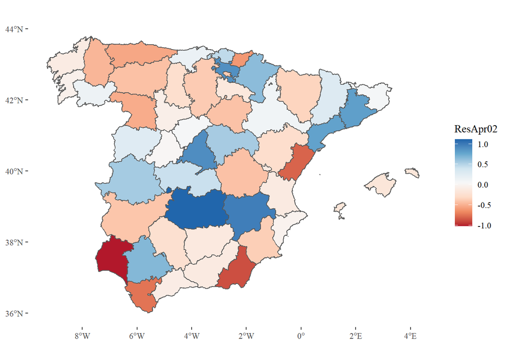

```r
covid19_spain %>% filter(Date == "2020-03-14") %>%
  mutate(ResApr02 = residuals_Apr02) %>%
  filter(CCAA != "Canarias") %>%
  ggplot() +
  geom_sf(aes(fill = ResApr02)) +
  scale_fill_distiller(palette = "RdBu", direction = 1) +
  theme_tufte()
```

## Temporal variation of coefficients of control variables

### Male to Female Ratio

- No es significativa

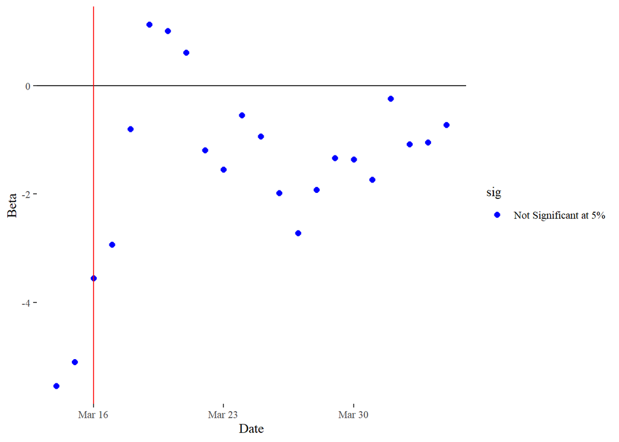

```r
n = 2
data.frame(Date = seq(ymd("2020-03-14"),
                        ymd("2020-04-04"),
                            by = "days"),
           Beta = matrix(sur.slm_lag11$coefficients,ncol = 22)[n,],
           tvalue = matrix(sur.slm_lag11$coefficients/sur.slm_lag11$rest.se,ncol = 22)[n,]) %>%
  mutate(sig = ifelse(abs(tvalue) > 1.64, "Significant at 5%", "Not Significant at 5%")) %>%
  ggplot(aes(x = Date, y = Beta, color = sig)) +
  geom_point(size = 2) +
  scale_color_manual(values = c("Significant at 5%" = "red", "Not Significant at 5%" = "blue")) +
  geom_hline(yintercept = 0) +
  geom_vline(xintercept = as_date("2020-03-16"), color = "red") +
  theme_tufte()
```

### Median Age

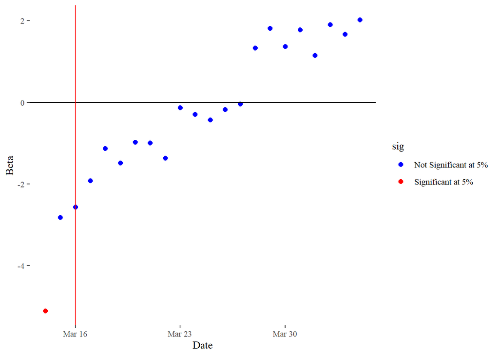

```r
n = 3
data.frame(Date = seq(ymd("2020-03-14"),
                        ymd("2020-04-04"),
                            by = "days"),
           Beta = matrix(sur.slm_lag11$coefficients,ncol = 22)[n,],
           tvalue = matrix(sur.slm_lag11$coefficients/sur.slm_lag11$rest.se,ncol = 22)[n,]) %>%
  mutate(sig = ifelse(abs(tvalue) > 1.64, "Significant at 5%", "Not Significant at 5%")) %>%
  ggplot(aes(x = Date, y = Beta, color = sig)) +
  geom_point(size = 2) +
  scale_color_manual(values = c("Significant at 5%" = "red", "Not Significant at 5%" = "blue")) +
  geom_hline(yintercept = 0) +
  geom_vline(xintercept = as_date("2020-03-16"), color = "red") +
  theme_tufte()
```

## Dinámica temporal de Variables Climáticas

### TEMPERATURA

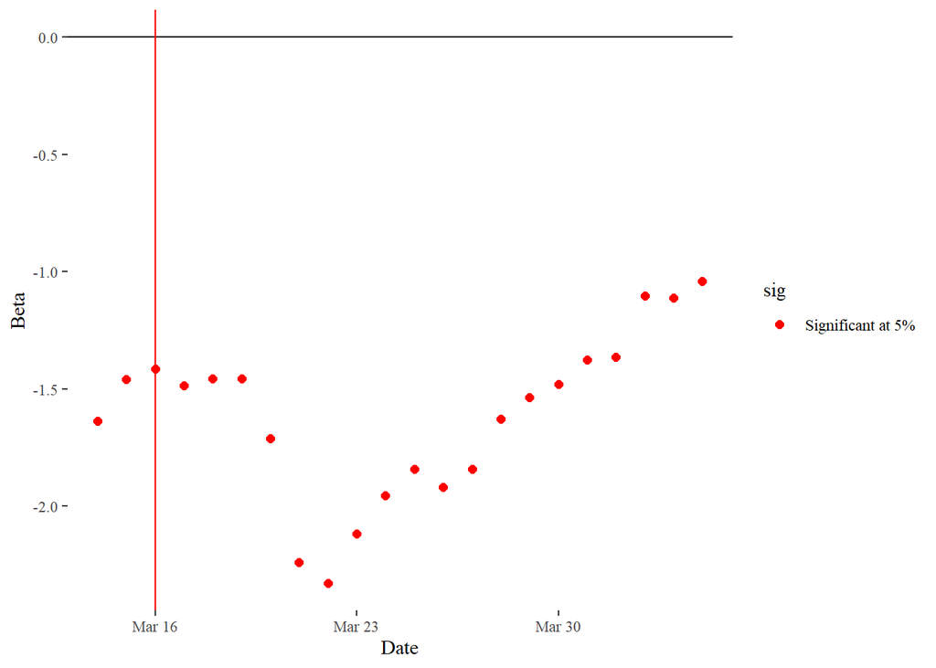

```r
n = 4
data.frame(Date = seq(ymd("2020-03-14"),
                        ymd("2020-04-04"),
                            by = "days"),
           Beta = matrix(sur.slm_lag11$coefficients,ncol = 22)[n,],
           tvalue = matrix(sur.slm_lag11$coefficients/sur.slm_lag11$rest.se,ncol = 22)[n,]) %>%
  mutate(sig = ifelse(abs(tvalue) > 1.64, "Significant at 5%", "Not Significant at 5%")) %>%
  ggplot(aes(x = Date, y = Beta, color = sig)) +
  geom_point(size = 2) +
  scale_color_manual(values = c("Significant at 5%" = "red", "Not Significant at 5%" = "blue")) +
  geom_hline(yintercept = 0) +
  geom_vline(xintercept = as_date("2020-03-16"), color = "red") +
  theme_tufte()
```

### Hours of sunshine

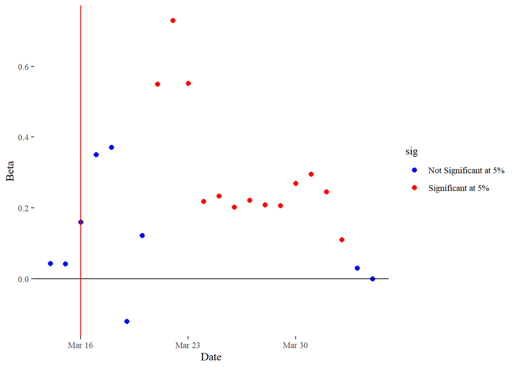

```r
n = 5
data.frame(Date = seq(ymd("2020-03-14"),
                        ymd("2020-04-04"),
                            by = "days"),
           Beta = matrix(sur.slm_lag11$coefficients,ncol = 22)[n,],
           tvalue = matrix(sur.slm_lag11$coefficients/sur.slm_lag11$rest.se,ncol = 22)[n,]) %>%
  mutate(sig = ifelse(abs(tvalue) > 1.64, "Significant at 5%", "Not Significant at 5%")) %>%
  ggplot(aes(x = Date, y = Beta, color = sig)) +
  geom_point(size = 2) +
  scale_color_manual(values = c("Significant at 5%" = "red", "Not Significant at 5%" = "blue")) +
  geom_hline(yintercept = 0) +
  geom_vline(xintercept = as_date("2020-03-16"), color = "red") +
  theme_tufte()
```

### Humidity

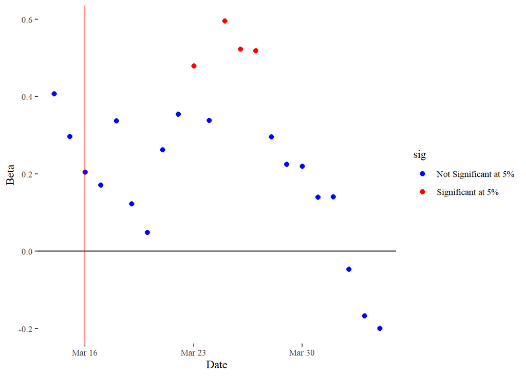

```r
n = 6
data.frame(Date = seq(ymd("2020-03-14"),
                        ymd("2020-04-04"),
                            by = "days"),
           Beta = matrix(sur.slm_lag11$coefficients,ncol = 22)[n,],
           tvalue = matrix(sur.slm_lag11$coefficients/sur.slm_lag11$rest.se,ncol = 22)[n,]) %>%
  mutate(sig = ifelse(abs(tvalue) > 1.64, "Significant at 5%", "Not Significant at 5%")) %>%
  ggplot(aes(x = Date, y = Beta, color = sig)) +
  geom_point(size = 2) +
  scale_color_manual(values = c("Significant at 5%" = "red", "Not Significant at 5%" = "blue")) +
  geom_hline(yintercept = 0) +
  geom_vline(xintercept = as_date("2020-03-16"), color = "red") +
  theme_tufte()
```

### Intercept

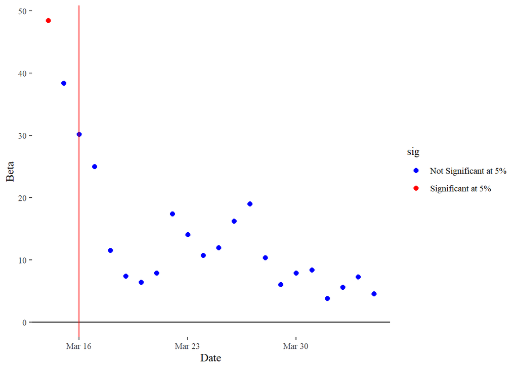

```r
n = 1
data.frame(Date = seq(ymd("2020-03-14"),
                        ymd("2020-04-04"),
                            by = "days"),
           Beta = matrix(sur.slm_lag11$coefficients,ncol = 22)[n,],
           tvalue = matrix(sur.slm_lag11$coefficients/sur.slm_lag11$rest.se,ncol = 22)[n,]) %>%
  mutate(sig = ifelse(abs(tvalue) > 1.64, "Significant at 5%", "Not Significant at 5%")) %>%
  ggplot(aes(x = Date, y = Beta, color = sig)) +
  geom_point(size = 2) +
  scale_color_manual(values = c("Significant at 5%" = "red", "Not Significant at 5%" = "blue")) +
  geom_hline(yintercept = 0) +
  geom_vline(xintercept = as_date("2020-03-16"), color = "red") +
  theme_tufte()
```